# Course Project 2

Roberto Nisti

7 de julho de 2016

We analized Storm data from USA to discovery which has more impact.

Libraries - We need this libraries to manipualted data

```r
library(dplyr)
library(data.table)
```

This is our source of information, explain about data, click in https://d396qusza40orc.cloudfront.net/repdata%2Fpeer2_doc%2Fpd01016005curr.pdf

```r
file_down <-
  download.file("https://d396qusza40orc.cloudfront.net/repdata%2Fdata%2FStormData.csv.bz2","storm_data.bz2")
storm_data <- read.csv("storm_data.bz2")
```

We only data about injuries, fatalities and damages

```r
injurie_data <- data.frame(storm_data$EVTYPE, storm_data$INJURIES,
                           storm_data$FATALITIES, storm_data$PROPDMG)
names(injurie_data) <- c("EVTYPE", "INJURIES", "FATALITIES", "PROPDAMAGE")
dat2 <- injurie_data
```

Cleaning and preparing data - description information is not standarlized, so we devided data between some categories. First we inserted a description “WATHELSE” in all register, if any description doesn’t match in any category, we included in “OTHER”

```r
dat2$EVTYPE <- gsub(dat2$EVTYPE, toupper(dat2$EVTYPE), dat2$EVTYPE)
```

```r
dat2$EVTYPE <- paste("WHATELSE", dat2$EVTYPE )
dat2$EVTYPE <- gsub('.*STORM.*', 'STORM', dat2$EVTYPE)
dat2$EVTYPE <- gsub('.*HEAT.*', 'HEAT', dat2$EVTYPE)
dat2$EVTYPE <- gsub('.*SNOW.*', 'SNOW', dat2$EVTYPE)
dat2$EVTYPE <- gsub('.*WIND.*', 'WIND', dat2$EVTYPE)
dat2$EVTYPE <- gsub('.*SUMMARY.*', 'SUMMARY', dat2$EVTYPE)
dat2$EVTYPE <- gsub('.*WARM.*', 'WARM', dat2$EVTYPE)
dat2$EVTYPE <- gsub('.*RAIN.*', 'RAIN', dat2$EVTYPE)
dat2$EVTYPE <- gsub('.*COLD.*', 'COLD', dat2$EVTYPE)
dat2$EVTYPE <- gsub('.*ICE.*', 'ICE', dat2$EVTYPE)
dat2$EVTYPE <- gsub('.*DRY.*', 'DRY', dat2$EVTYPE)
dat2$EVTYPE <- gsub('.*TORN.*', 'TORNADO', dat2$EVTYPE)
dat2$EVTYPE <- gsub('.*LOW.*', 'COLD', dat2$EVTYPE)
dat2$EVTYPE <- gsub('.*WINTER.*', 'COLD', dat2$EVTYPE)
dat2$EVTYPE <- gsub('.*DRIE.*', 'DRY', dat2$EVTYPE)
dat2$EVTYPE <- gsub('.*WINTER.*', 'WINTER', dat2$EVTYPE)
dat2$EVTYPE <- gsub('.*FREEZA.*', 'WINTER', dat2$EVTYPE)
dat2$EVTYPE <- gsub('.*FREEZE.*', 'WINTER', dat2$EVTYPE)
dat2$EVTYPE <- gsub('.*HAIL.*', 'HAIL', dat2$EVTYPE)
dat2$EVTYPE <- gsub('.*HURRICANE.*', 'HURRICANE', dat2$EVTYPE)
dat2$EVTYPE <- gsub('.*FLOO.*', 'FLOOD', dat2$EVTYPE)
dat2$EVTYPE <- gsub('.*STREAM.*', 'FLOOD', dat2$EVTYPE)
dat2$EVTYPE <- gsub('.*HIGH.*TEMPER.*', 'WARM', dat2$EVTYPE)
dat2$EVTYPE <- gsub('.*HOT.*', 'WARM', dat2$EVTYPE)
dat2$EVTYPE <- gsub('.*COOL.*', 'WINTER', dat2$EVTYPE)
dat2$EVTYPE <- gsub('.*FROST.*', 'WINTER', dat2$EVTYPE)
dat2$EVTYPE <- gsub('.*FIRE.*', 'FIRE', dat2$EVTYPE)
dat2$EVTYPE <- gsub('.*WHATELSE.*', 'OTHER', dat2$EVTYPE)
```

Data about Injuries

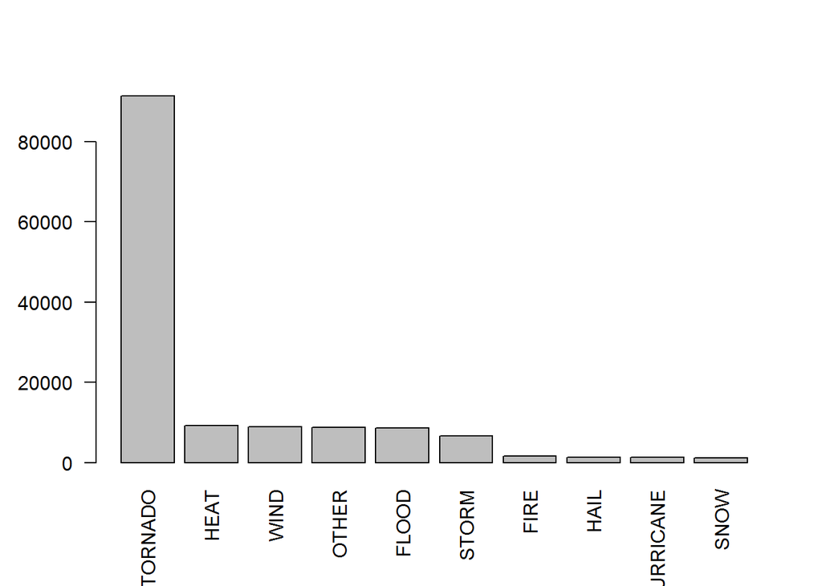

```r
x <- aggregate( dat2$INJURIES ~ dat2$EVTYPE, dat2, sum)
names(x) <- list("EVTYPE", "INJURIES")
z <- subset(x, x$INJURIES != 0)
names(z) <- list("EVTYPE", "INJURIES")
z <- arrange(select(z, EVTYPE, INJURIES), desc(INJURIES))[1:10,]
barplot(height = z$INJURIES, names.arg = z$EVTYPE, las=2)
```

Data about Fatalities

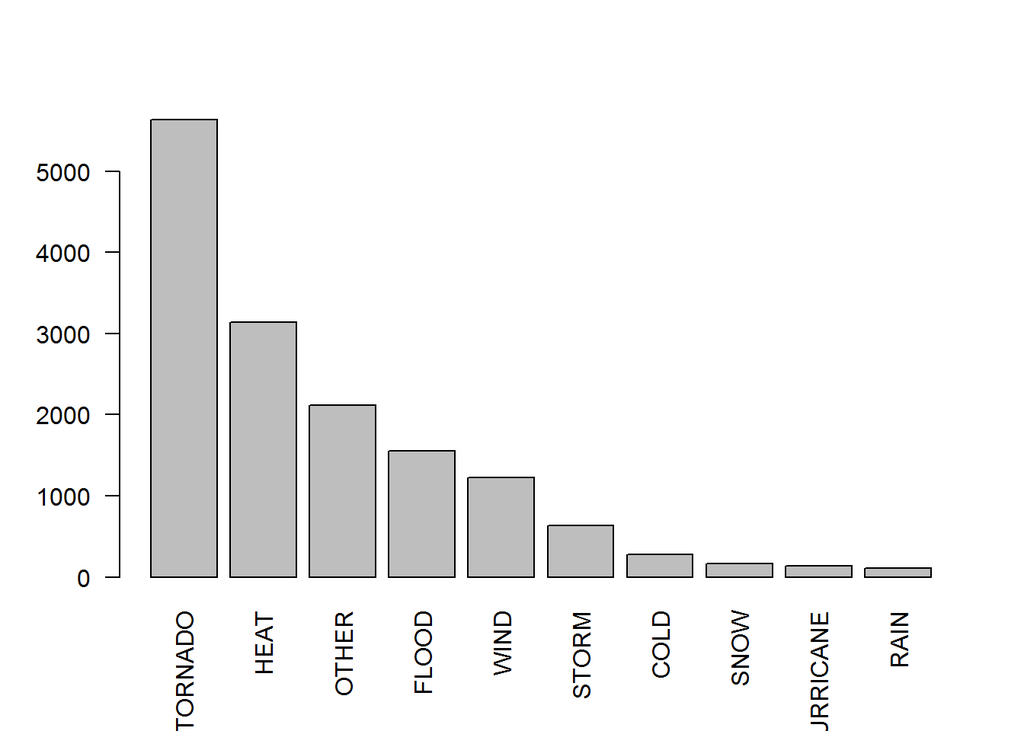

```r
x <- aggregate( dat2$FATALITIES ~ dat2$EVTYPE, dat2, sum)
names(x) <- list("EVTYPE", "FATALITIES")
z <- subset(x, x$FATALITIES != 0)
names(z) <- list("EVTYPE", "FATALITIES")
z <- arrange(select(z, EVTYPE, FATALITIES), desc(FATALITIES))[1:10,]
barplot(height = z$FATALITIES, names.arg = z$EVTYPE, las=2)
```

Data about Damage

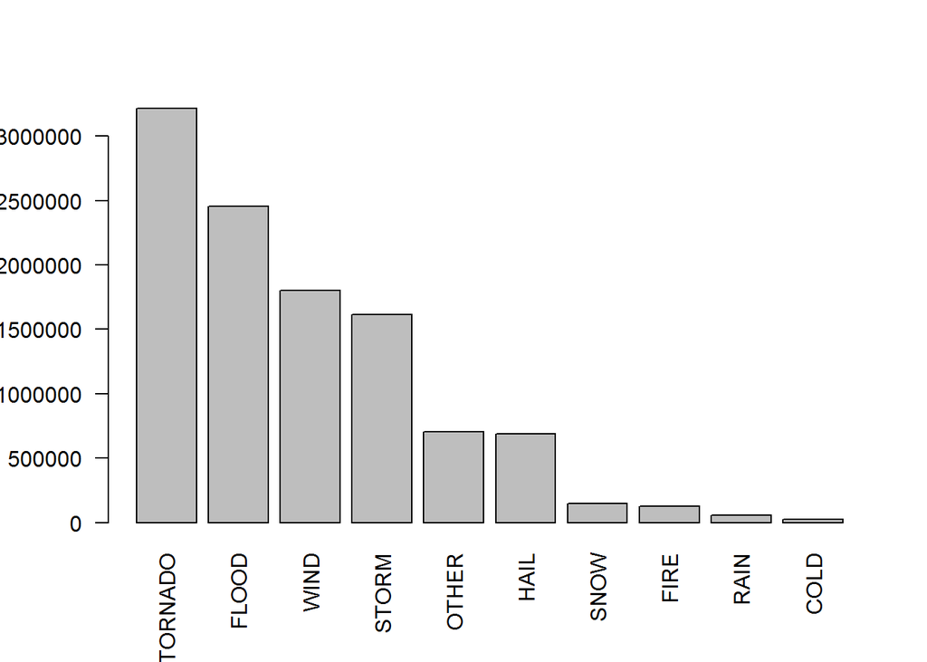

```r
x <- aggregate( dat2$PROPDAMAGE ~ dat2$EVTYPE, dat2, sum)
names(x) <- list("EVTYPE", "PROPDAMAGE")
z <- subset(x, x$PROPDAMAGE != 0)
names(z) <- list("EVTYPE", "PROPDAMAGE")
z <- arrange(select(z, EVTYPE, PROPDAMAGE), desc(PROPDAMAGE))[1:10,]
barplot(height = z$PROPDAMAGE, names.arg = z$EVTYPE, las=2)
```